# Data Privacy Survey

Signalling challenges and improvements of privacy-related services for research

Dorien Huijser

Neha Moopen

07 juni 2022

Abstract

In the second quarter of 2022, Utrecht University (UU) Research Data Management Support sent out a survey among all scientific personnel at UU: the Data Privacy Survey. The aim of this survey was to investigate 1) How UU researchers currently deal with personal data in research, 2) What challenges they run into when handling personal data in research, and 3) How RDM Support and collaborators can improve their services and support concerning personal data in research. The current report contains a summary of the results of this survey, as well as points of action to be taken.

# Introduction

Scientific research often includes some form of personal data. The amount of personal data in research is likely underestimated, as researchers may be unaware of what personal data are or whether they are being collected. With the implementation of the General Data Protection Regulation (GDPR) in May 2018, stricter legal requirements apply to handling personal data and its sharing or publication. The number of (complex) questions on handling personal data in scientific research is increasing. Yet, practical information to resolve these questions can be difficult to find, scattered, and/or discipline-specific. As such, there is room to better translate the legislation to scientific research practice and to provide practical tools for handling personal data in research.

This room for better translation is exemplified in the [Data Privacy Project](https://utrechtuniversity.github.io/dataprivacyproject/), a data support effort[^1] within Utrecht University (UU), the Netherlands. The project aims to build knowledge and expertise on how researchers can and should deal with personal data. The project’s deliverables are all focussed on providing practical, actionable and FAIR (Findable, Accessible, Interoperable, Reusable) information and tools for researchers to use in their research [^2].

To properly take into account the challenges and needs of our target audience, namely UU researchers, one of the deliverables of the project is to perform quantitative and qualitative investigations into the current practices and needs of UU researchers concerning the handling of personal data. Our primary research questions are:

1. To what extent are UU researchers aware of privacy legislation and practices?
2. What data privacy issues do UU researchers typically run into?
3. What support do UU researchers need to handle personal data?

To answer these questions both quantitatively and qualitatively, we have set up an online survey and planned one-on-one meetings with a selection of UU researchers. This report describes our methods, results and the future steps that data support at UU can take to improve their services concerning privacy in research.

# Methods

## Data Privacy Survey

### Survey questions

The Data Privacy Survey was created by the project coordinators (DH, NM) with input from the Data Privacy Project team, consisting of privacy officers, data managers, data consultants, information security and research engineering. The final version of the survey in Qualtrics consisted of 19-23 questions, which were separated into 5 sections:

1. *About you and your research*: 5 questions about the faculty, department, position, and type of (personal) data the researcher works with.
2. *Measures and documents*: 4-6 questions about researchers’ familiarity and use of privacy-related measures (e.g., processing register, Data Privacy Impact Assessment, encryption, pseudonymisation, etc.), data storage, and informed consent forms.
3. *Data sharing, archiving and publication*: 3-4 questions about researchers’ data sharing and publishing practices.
4. *Finding support*: 3-4 questions about the awareness of several data support channels.
5. *Improving our services*: 4 questions about researchers’ challenges, needs, and suggestions to improve UU’s data privacy support.

The estimated 10 minute duration of the survey in advance proved to be relatively accurate: respondents spent an average of 8.5 minutes on the survey (range: 0.4 minutes - 5.1 days). The majority of researchers (82.7%) fully completed the survey.

### Procedure

The survey was distributed from March 21st, 2022 onwards via several communication channels to reach as many UU researchers as possible:

- An [email](https://utrechtuniversity.github.io/dataprivacyproject/20220321-data-privacy-survey.html) was sent to all academic staff at UU through central communication channels. The reasoning was that this would be the most effective way to reach as many UU researchers as possible (taking for granted that we would likely miss a small part of non-academic personnel also involved in research in some way).
- A mention in several Faculty newsletters.
- Social media messages (e.g., on [Twitter](https://twitter.com/RDMsupportUU/status/1517390979707412481)).
- A [news item](https://intranet.uu.nl/en/news/news-items/survey-better-support-for-handling-privacy-sensitive-data-in-research) on the UU intranet.
- Via data support colleagues, who were asked to point researchers they were in contact with to the survey.

Researchers could decide voluntarily whether they wanted to participate in the survey. The survey only started after they had provided their consent. All results reported here are from researchers who provided their active consent.

### Survey respondents

The survey was filled out by 173 UU researchers. The survey was created in such a way so that only researchers from a UU faculty, who worked with personal research data, were selected to respond to all other survey questions.

We received responses from each faculty, but the distribution is not equal: the faculties of Science and Social and Behavioural Sciences are overrepresented, whereas the responses of the Faculty of Geosciences and the Faculty of Medicine are rather low. This can be explained by the fact that a large chunk of research performed at the Faculty of Geosciences does not investigate human behavior and therefore does not work with personal data much. The Faculty of Medicine, then, is located at the University Medical Center Utrecht (UMCU) and is not of primary interest for the current survey, as it concerns an entirely different organisation with a separate research support structure.

As can be seen in the figure on the right, most respondents are early career researchers (PhDs, junior researchers and postdoctoral researchers). We suspect that this is because 1) there simply are more early-career researchers than mid- and late career researchers, and 2) early-career researchers experience a greater need for support with respect to handling personal data.

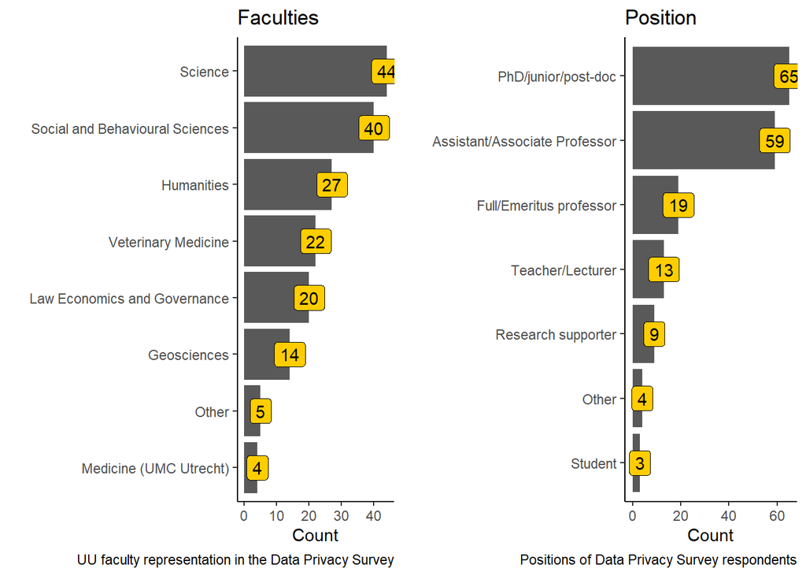

### Analysis

Below we report on the descriptive statistics or summaries from most of the survey questions. As we did not formulate hypotheses, no statistical analyses were performed.

### Data and material availability

The entire survey can be found [on our website](https://utrechtuniversity.github.io/dataprivacyproject/assets/docs/survey-questions-qualtrics.pdf), as well as the separate [privacy statement](https://utrechtuniversity.github.io/dataprivacyproject/assets/docs/survey-privacy-statement.pdf). The script can be found in the designated [GitHub repository](https://github.com/UtrechtUniversity/dataprivacysurvey). As the raw data contain personal information (IP address, demographic information, open text responses and email addresses), and no consent was obtained to share those details, we are unable to share them.

## One-on-one meetings

Besides the survey, we aimed to organise one-on-one meetings with researchers, to hear more in-depth experiences, challenges and needs concerning handling personal data in research. Survey respondents could voluntarily leave their email address at the end of the survey to be contacted by us.

From the survey respondents, 40 researchers left their email address to be contacted. Of those, 22 replied to our email asking to meet up. So far, 18 one-on-one, mostly online, meetings of have been conducted, each taking about 30 minutes. During the meetings, at least one of the project coordinators was present, together with either the other project coordinator or the relevant faculty privacy officer.

Below, the division over faculties can be seen for all respondents that left their email address:

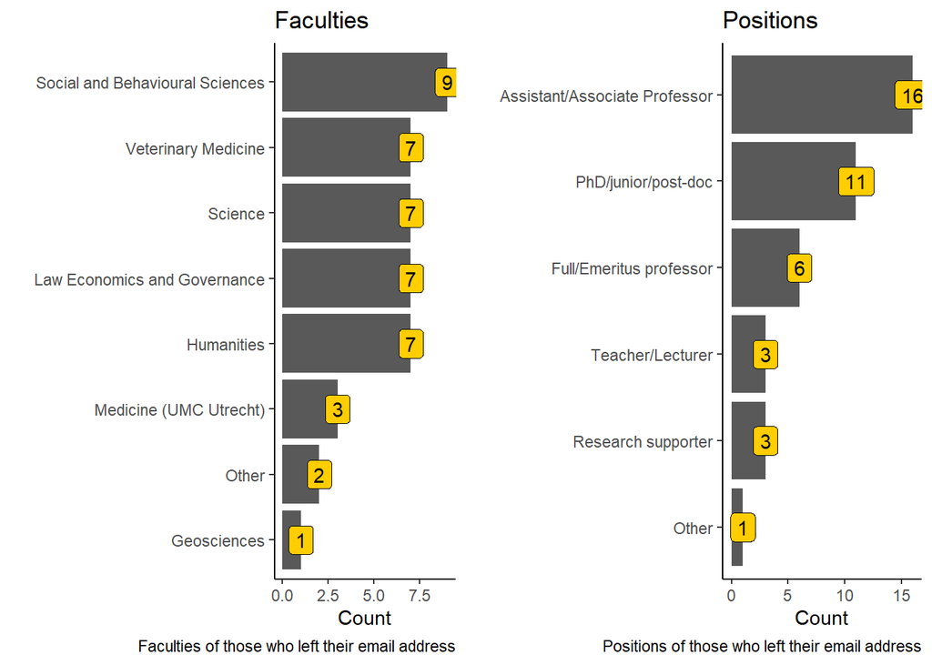

# Results

## Types of research data

Within the sample of the survey, it is clear that most researchers use tabular, textual, code and audio data as their primary research data format. The most encountered type of *personal* data that researchers indicate to work with are contact information, demographic information and direct identifiers. This can be either because these are the types of personal data that are indeed most common, or because researchers mostly recognize these types of data as being personal data.

Types of data used among survey respondents

| Datatype | Count | Percentage |
| --- | --- | --- |
| Tabular data | 123 | 71.1 |
| Textual data | 106 | 61.3 |
| Code/theoretical models | 60 | 34.7 |
| Audio data | 56 | 32.4 |
| Video data | 39 | 22.5 |
| Images | 38 | 22.0 |
| Bio-medical samples and data | 28 | 16.2 |
| Physiological measurements | 27 | 15.6 |
| Geographical data | 24 | 13.9 |
| Physical samples | 11 | 6.4 |
| Other | 8 | 4.6 |

Types of personal data used among survey respondents

| Personal Datatype | Count | Percentage |
| --- | --- | --- |
| Demographic information | 102 | 59.0 |
| Contact information | 80 | 46.2 |
| Direct identifiers | 66 | 38.2 |
| Sensitive demographic information | 35 | 20.2 |
| Human behaviour | 32 | 18.5 |
| Derived personal data | 30 | 17.3 |
| Health/physical information | 25 | 14.5 |
| None | 18 | 10.4 |
| Other | 11 | 6.4 |
| Sensitive direct identifiers | 9 | 5.2 |

## Current practices in handling personal data

The first part of the survey addressed the researchers’ current practices in handling personal data in their research.

### Organisational and technical measures

With respect to organisational and technical measures used to handle personal data, most researchers indicate they pseudonymise/anonymise their data. We cannot, however, assess whether the data is sufficiently pseudonymised/anonymised in line with the GDPR. Researchers also implement some form of access control and complete data management plans (DMPs). Agreements, such as NDAs, are utilized to some degree as well. On the other hand, GDPR-specific assessments such as DPIAs or privacy reviews are least used - as it stands, these assessments are still only carried out on a case-by-case basis.

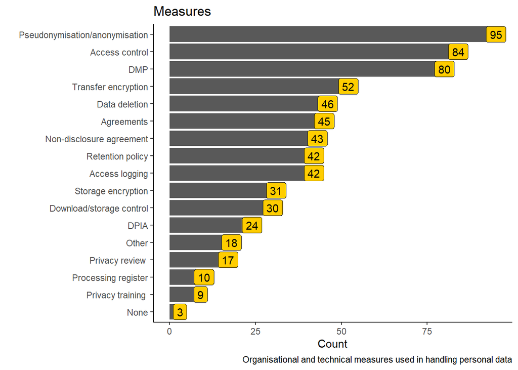

### Storage media used

To store personal data, most researchers rely on storage solutions provided by UU. Nonetheless, some researchers utilize non-UU solutions, including non-UU cloud storage. Several researchers also indicated they use ‘Other’ storage solutions. Examples of these include external institutions (e.g., University Medical Center, Trimbos Institute, Central Bureau of Statistics) and external repositories (e.g., DANS EASY, CLARIAH).

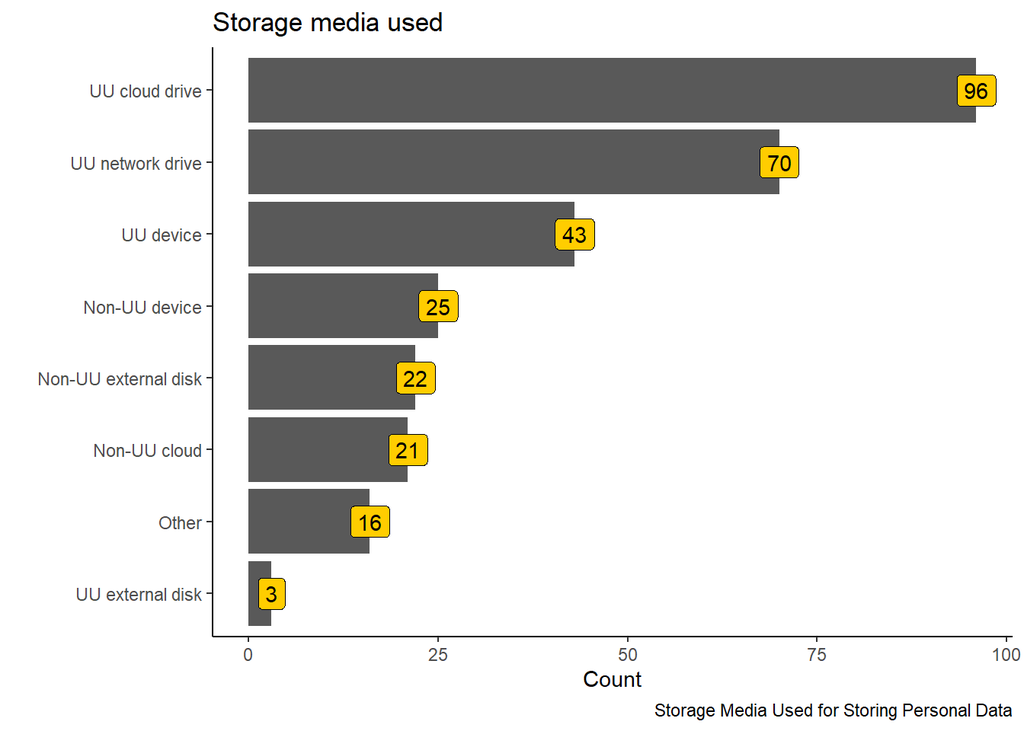

### Consent forms: usage and content

Only a small number of researchers indicate that consent forms are not applicable to their research or they don’t know what they are. When researchers do use consent forms, they often use forms approved by privacy officers or ethical committees. Researchers however also indicate they tend to independently create and use forms. Departmental and UU-wide templates are also used to a fair extent. Some researchers (“Other”) indicate to use templates from external institutions, or no templates at all (e.g., because they use verbal consent or data from another party).

Within the consent forms, most researchers provide information on the purposes for data collection and which data will be be used. Information on the data subject’s rights and safeguards are included as well. Information on data sharing and reuse is presented sometimes, but not as consistently as the aforementioned topics.

Most researchers indicate that ‘regular’ consent is explicitly requested, but consent to data sharing and further use is not always requested. This is a point of concern, because it may not be sufficient to merely inform data subjects that their data may be shared or reused, but data subjects should explicitly provide permission for their data to be used beyond the research project they signed on to.

Lastly, contact details of the DPO are not always included, whereas these always have to be provided ([art. 13](https://gdpr-info.eu/art-13-gdpr/))

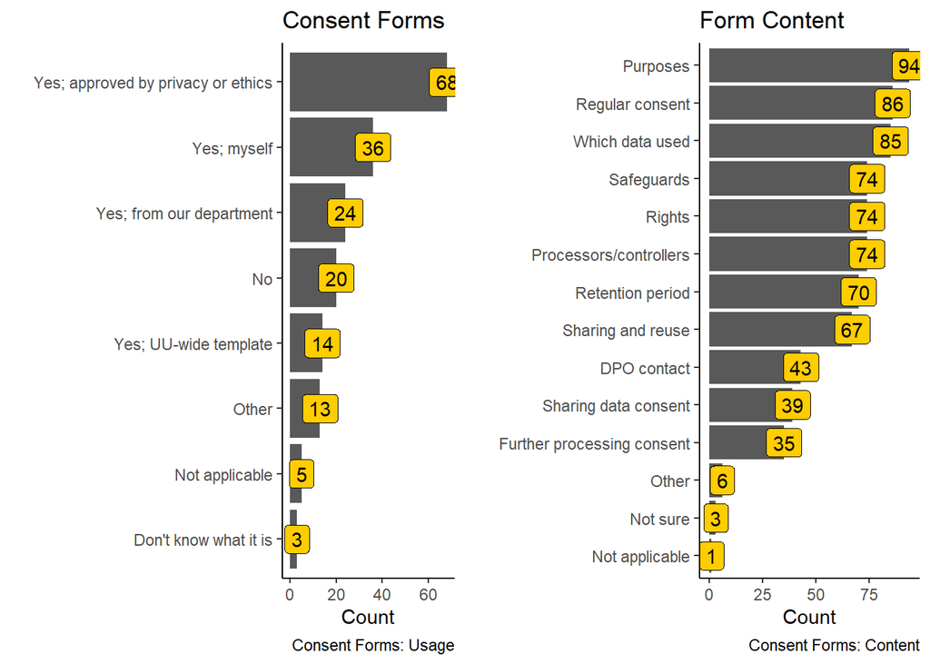

### Data Protection Impact Assessment (DPIA)

Most of the researchers who responded to the survey indicate that they have never carried out a DPIA, nor had they ever heard of it. A small number of researchers have heard of DPIAs, but have not completed one. A similar number researchers indicated that they are familiar with and have completed a Data Protection Impact Assessment (DPIA). Most of these researchers received help from a Privacy Officer with their DPIAs and few received help from either RDM Support or Legal Affairs. Some researchers indicated they received ‘Other’ help or none at all.

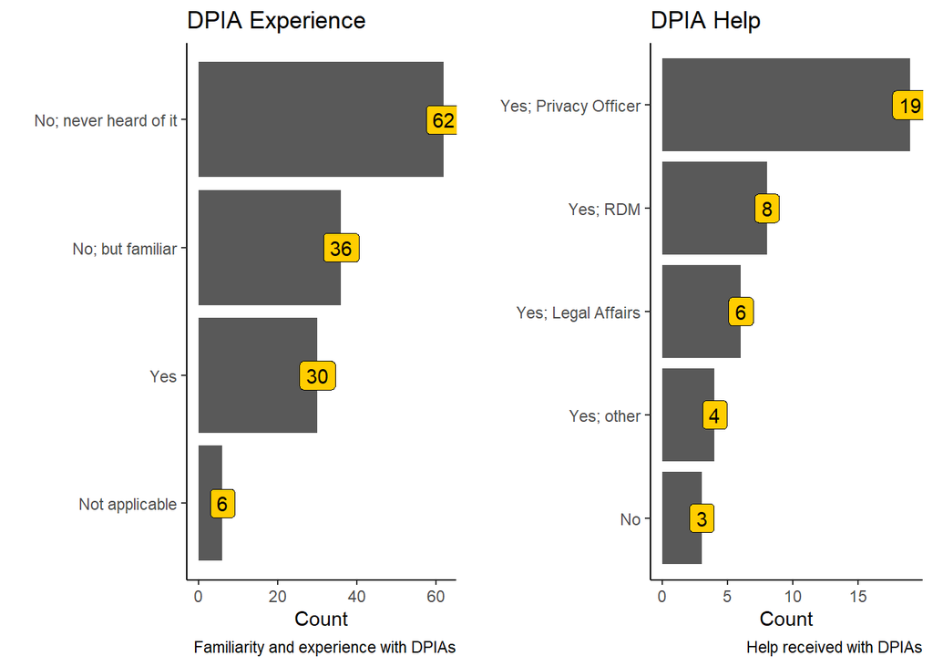

### Data sharing practices

While there are some researchers who don’t share their data at all, most researchers who responded to the survey indicate they do not share data with external parties, but only within the UU. A smaller number of researchers indicated they share data within the EEA. Responses in the “Other” category however suggest that a lot of data actually is shared, for example with co-authors at another institution, students, or in “pseudonymised form”. There are researchers who share data outside the EEA, most of these with countries deemed to have an adequate level of protection according the GDPR. Only a few share with countries without an adequate level of protection.

Most researchers pseudonimise their data before sharing with external parties, though we cannot assess if this pseudonymisation is sufficient. Researchers also make use of approved tools, data transfer agreements, data processing agreements, and providing access without transfering the data. Fewer researchers indicate that they involved a Privacy Officer or Data Manager while transferring data, and the use of Standard Contractual Clauses appears limited.

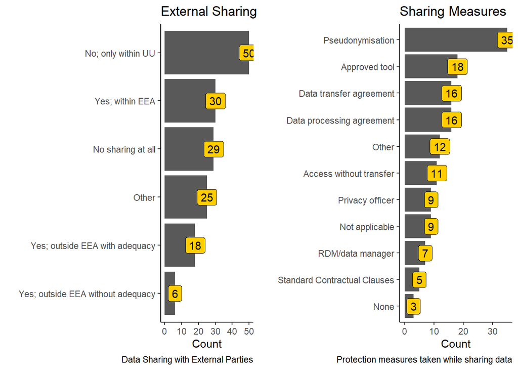

### Data publishing

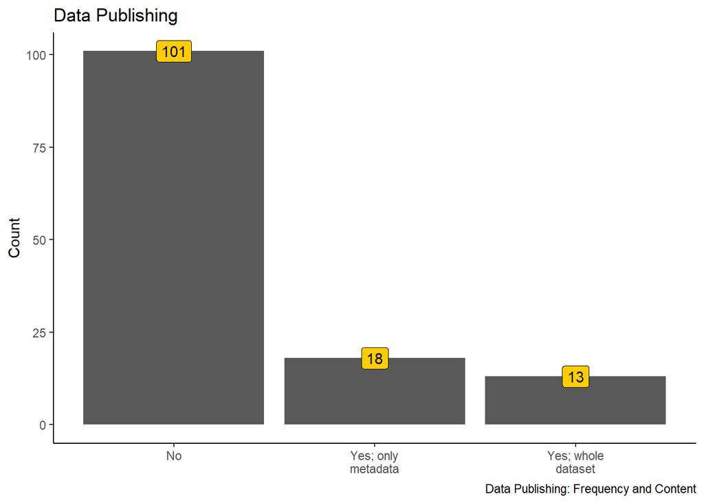

The majority of researchers who responded to the survey indicate that they do not publish their data in any way or form. The primary reason for not publishing data appears to be that researchers are still working on the data. Nonetheless, many researchers indicate that they don’t want to/need to publish their data, or they cannot anonymise the data. Other reasons include a lack of legal basis, not knowing if they’re allowed to publish the data, too much effort, publication is undesirable, or just not considered. Finally, only a few researchers indicate that they don’t know how to publish data at all

If a publication is made, most researchers tend to publish the metadata only while fewer publish the entire data set. Researchers tend to publish anonymous data primarily, followed by pseudonymised data. As with previous responses, it is not possible to assess whether this anonymisation or pseudonymisation was adequate.

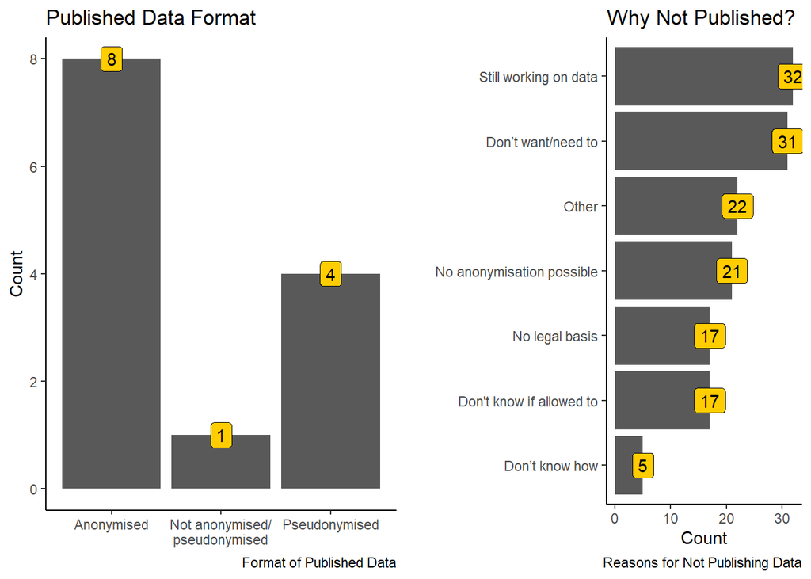

## Existing support channels

### Faculty privacy officer

The second part of the survey concerned the visibility and use of existing support channels. When asked whether respondents know who their faculty privacy officer is, most respondents indicated that they do not (Yes: 64 (37%), No: 67 (37%), NA: 42 (24%)). This suggests either that researchers have simply never required help from their privacy officer, or that the faculty privacy officers could increase their visibility within their faculties.

### Looking for help

When asked whether respondents have ever looked for support in the form of information, tools, or support an overwheling majority indicated that they have, as can be seen in the graph below. Most respondents that looked for support indicate however that they haven’t always found the suport they were looking for. Together with the results from the previous question about privacy officers, this suggests that the visibility of the current support channels could be improved.

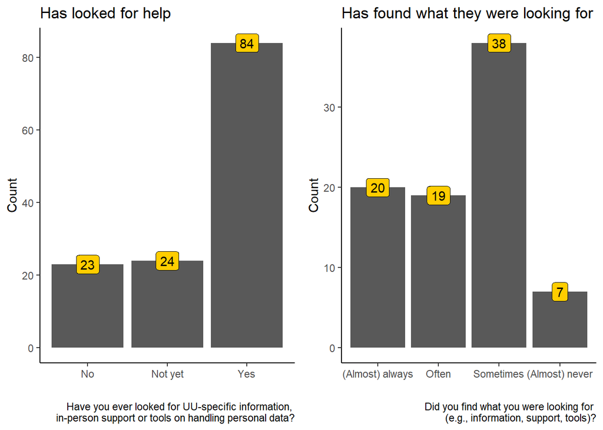

### Channels used to find support

The graph below indicates which channels respondents to the survey used most when looking for information about handling personal data. Note that this was a multiple choice question, and so the numbers do no add up to the total number of survey respondents. As shown below, all sources mentioned are to some extent consulted by the respondents. However, there is large differentiation between these sources. The university website and intranet are the most visited online resources for information about handline personal data. Notably, colleagues appear to play an important role as well in informing researchers about how to handle personal data.

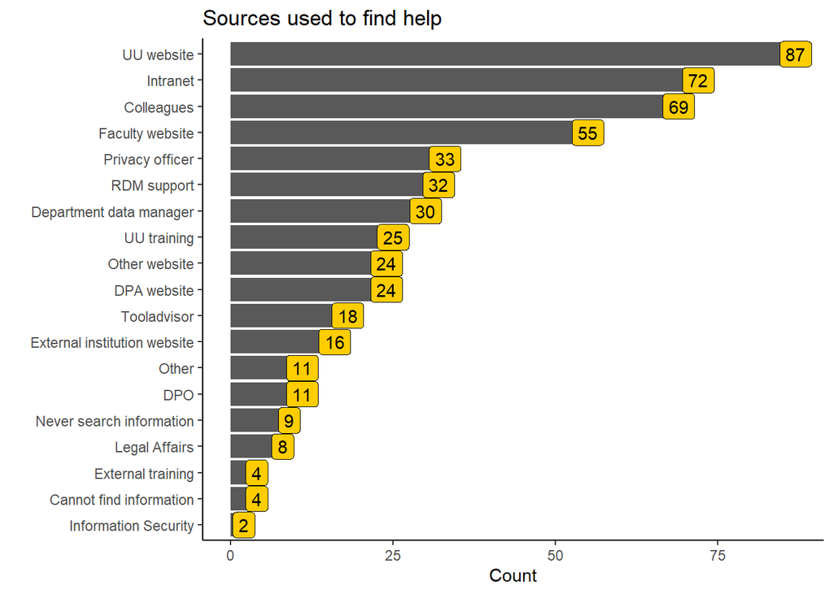

## Challenges and needs (survey)

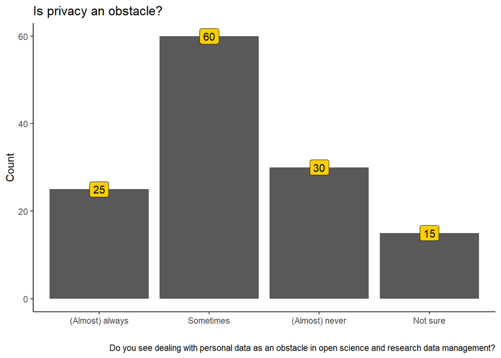

As can be seen above, most researchers experience privacy an obstacle for open science and research data management. It is therefore important to aim for better service and support in this area. What this support should look like differs a bit:

How can we improve personal data-related services?

| bettersupport | Count | Percentage |
| --- | --- | --- |
| Information | 76 | 43.9 |
| Support visibility | 66 | 38.2 |
| UU-wide policy | 46 | 26.6 |
| Walk-ins | 34 | 19.7 |
| Workshops | 29 | 16.8 |
| Other | 27 | 15.6 |
| Support availability | 25 | 14.5 |
| Tooling | 24 | 13.9 |
| Trainings | 23 | 13.3 |

The open text responses reveal the following challenges and needs:

- **Knowledge gaps**: A selection of researchers use the space in the open questions to ask knowledge-related questions, such as: “How far should one go before data can be considered fully anonymous?” (n = 5), “What counts as personal data?” (n = 7), “How to make sure data are fully deleted?” (n = 1), and “What to do when only a selection of data subjects has consented to data sharing?” (n = 1). These questions can be addressed in future support efforts, such as to be developed information materials and trainings.
- **Time-intensive and bureaucratic**: Processes are often experienced as being time-inefficient, and sometimes longer and more bureaucratic than necessary. Some researchers argue that (part of) this burden should be relieved or carried by support staff:

  > “Sharing data costs a lot of time and is inefficient when you do not do it often”

  > “Minder acties die gericht zijn op inhoudelijk trainen van WP en meer uit handen nemen van deze groep.”
- **Unclear expectations and support channels**: There is unclarity in the exact requirements for researchers: what does the process look like? Who should they ask for help, and with what kinds of questions?

  > “There is no one who tells at the start of your PhD how you should handle your data. […] I think new PhD students should get a basic course on data management and privacy.”
- **More hands-on support**: Some researchers find that support staff could sometimes provide support in a more hands-on fashion, rather than abstract advice and telling researchers how *not* to do things. Some researchers add that privacy professionals have a tendency to cling to the letter of the law, instead of looking at how to apply the GDPR in practice:

  > “I find that there is a severe lack of trust in employees”

  > “Soms zijn we door deze regels heiliger dan de paus.”
- **Specific data types**: Many researchers express the need for practical guidelines, tools and templates, and on specific types of data (e.g., etnographic, historic, linguistic, video data, etc.) or in specific scenarios. Multiple researchers indicate that existing solutions are not always suitable for their type of research, or that there are no (standardised) guidelines available at all.

  > “De informatie is gewoon veel te generiek, er zouden templates moeten zijn per type onderzoek.”

  > “Veel templates en uitlegmodellen spreken over data, data packages en metadata, maar die woorden zijn niet ingebed in historisch onderzoek. Er ontstaat al snel verwarring over wat historici nu precies moeten met archiefmateriaal in het licht van privacy.”
- **Specific tools**: Some researchers express a need for a concrete (improvement of a) tool, such as for pseudonymising video data (n = 4), transcribing audio data (n = 4), and sharing data with others (n = 3).

Importantly, there are also researchers who indicate **not** to have run into any issues or to have received sufficient and useful help:

> “The data manager and privacy officer of the faculty of humanities help a lot. This support is essential!”

> “Tot nu toe heb ik niet veel problemen gehad. De institutional review board van onze afdeling kijkt altijd kritisch naar de onderzoeksvoorstellen, ook met name op omgaan met persoonsgegevens.”

## Challenges and needs (meetings)

As the one-on-one meetings are currently conducted, a summary or the results will be added at a later time.

# Results summary [preliminary]

In this survey, we find that personal data are processed in each faculty and across all academic positions at Utrecht University. Most researchers have tabular, textual, code and audiovisual datasets, which contain all kinds of personal data (mostly demographics, contact information, direct identifiers).

Most researchers are familiar with concepts like anonymisation and pseudonymisation, access control, and UU-approved tools for handling personal data. However, the knowledge level differs quite a bit. For example, some researchers seem to store data on locations that officially are not allowed. Data is often shared, but not all the right measures are always taken to do so securely. Additionally, some measures to securely handle personal data in accordance with the GDPR are less known, or there is confusion about it. For example, the processing register, Data Protection Impact Assessment, and Standard Contractual Clauses are among the least known concepts that we measured. And there seems to be unclarity among part of the respondents on when sharing data is allowed or when data are personal. Together, this suggests that there is a lot to be gained regarding awareness and secure practices in scientific research with personal data.

Below, we summarise challenges and needs explicated by researchers.

# Recommendations [preliminary]

## Increased visibility

Our data show that the visibility of existing support for handling personal data can be increased at UU. This includes visibility of privacy officers, legal affairs and Research Data Management Support, as well as faculty- or department-level support.

As shown by the fact that many respondents consult with colleagues for information and support, personal contact with supporters will likely be more effective at increasing awareness and uptake of secure privacy practices than a passive website that may not always answer all possible questions.

Some suggestions for increasing visibility:

- Make sure there is (sufficient) support available to help researchers in time. If there is no support available, the odds are that researchers may not ask for help at all and thus forget important privacy elements in the design of their research project.
- Make sure support staff are easy to find. For example, give them a clear location on the university website and/or on the intranet. Also indicate who is available for what type of support and for which target audience (e.g., “all UU researchers”, “employees from the Faculty of Humanities”, etc.)
- Make sure information on handling personal data in research is easy to find. The UU website and intranet seem the most suitable places, as these are the most visited to look for information according to the survey.
- Make researchers actively aware of existing support channels. For example, first-line support can visit important faculty or department events, offer to give a workshop, and keep short lines of contact with department heads.

## More hands-on support

The survey and interviews show that some researchers are not content with the support they have received in the past. For example, their research project may have suffered significant delays due to the fact that support personnel only pointed them at what they could *not* do, rather than how to solve privacy- related issues. We noticed many researchers that argue for more hands-on suppport, rather than advise with no concrete direction how to apply it in practice. More hands-on support can for example be reached by:

- More collaboration between different types of data support. For example, at UU there is a clear distinction between privacy officers (employed by faculties), data managers (employed by the University Library and some faculties), information security officers (Information Technology Services) and research engineers (Information Technology Services). However, in practice there is often overlap between either or all of these positions. Regular collaboration between these parties can:
  - help privacy and security experts understand the perspective of the researcher and possibly how to apply their advice in practice,
  - help data managers and research engineers understand the GDPR requirements and translate those to practice, and
  - enable reuse of solutions already applied in earlier cases that either party may not be aware of.
- Together with researchers, developing suitable practical solutions (tools, protocols, etc.) for specific scenarios and/or types of research, and sharing them with the world for reuse (if possible).
- Increasing contact between support staff and researchers to understand the issues they are dealing with that require a solution.

## Decreased administrative burden

A selection of researchers mention a high administrative burden when handling personal data. This is for example expressed in processes that take too long (e.g., writing and reviewing a Data Privacy Impact Assessment) and too many forms to be filled out with overlapping content (e.g., privacy review, Data Management Plan, processing register, DPIA). We suggest that these issues can be partly attributed to:

1. Understaffing: it is currently impossible for data support staff to review all research projects involving personal data that are undertaken at UU. This can lead to projects with issues being noticed too late and researchers having to change their timeline or even project as a whole after the fact. This creates unnecessary administrative burden that could have been prevented had researchers been in contact with support staff.
2. Lack of unifying policy on steps to take when working with personal data. At the moment each faculty has its own procedure, or has none at all. This can create confusion among both researchers and support staff on which steps to take when, who to contact for help, or who is responsible for deciding on compliance.
3. Lack of integration between systems and staff: having to fill out the same thing multiple times may be caused by the fact that different administrative systems are used for different purposes. Integration of these systems may lead to a relief of the administrative burden experienced by researchers.  
   For example, DMPonline is used at UU for registering Data Management Plans. However, DMP templates do not include sufficient questions about how personal data are handled, and thus a privacy plan or review may be required. Privacy is sometimes part of an ethical application, and so this same information may be included there again as well. Finally, the processing register also requires information on (among others) the type and sensitivity of personal data, which is a third system where this information will be registered.

## Education and outreach

Many problems seem to arise from the fact that privacy has not been taken into account from the design phase of a research project. This leads to research support staff being contacted too late in the process, who then has to tell the researcher to retrospectively make changes in their design in order to move forward.

Such scenarios may be prevented by, for example:

- Including the basic of handling personal data and contact details of support staff in onboarding processes when researchers are newly hired.
- Educating researchers on taking privacy into account in the designing phase of their project.
- Organising outreach events, such as the “Privacy and Security week” making researchers aware of privacy-related measures (see further Visibility).
- Embedding privacy in existing materials and processes, such as in ethical applications, in the education of research master and PhD students, etc.

# Discussion

This report summarised the findings of the Data Privacy Survey and our recommendations on what to do with the input we have received. In order to interpret these results correctly, there are a few matters that need to be taken into account:

1. The respondents of the survey represented only a small selection of all of UU’s Scientific Personnel. Therefore, the results presented here should not be overgeneralized to represent all of UU’s researchers. It is likely that at least part of the respondents had a specific reason to do so. For example, they may have explicitly wanted to raise their voice because of some bad experiences in handling personal data in research. Although it is important that these concerns be heard, they should not be interpreted as to speak for all UU researchers.
2. It is important to note that we, the writers of this report, cannot be considered fully objective in interpreting the survey results. The feedback received via this survey also involves our own services and possibly work performance. Although we have attempted to interpret the results of the survey without bias, it is possible that we have indeed introduced some, especially where the open questions and one-on-one meetings are concerned.
3. The questions in this survey intentionally do not address at which data support personnel the feedback is targeted. This also means that our recommendations do not specify Who within the organisation should pick them up. Preferably, these recommendations will be picked up by a collaboration between data support at different levels of the organisation (departmental, faculty, central) and, if needed, beyond, to address researchers’ concerns and improve the support surrounding the handling of personal data in research.

# Technical information

This document was last created on: 2022-06-07.

[^1]: The Data Privacy Project is led by Utrecht University’s [Research Data Management Support](https://uu.nl/rdm/), a collaboration between the University Library and Information Technology Services, but there is a tight collaboration with other data support, such as first- and second-line privacy officers and information security.
[^2]: The project is funded by Utrecht University’s Research IT program and a Digital Competence Center grant from the Dutch Organization for Scientific Research (NWO).